# Making the invisible differences visible

## Executive Summary

Recommendation for blended reporting

- prepare printable reports, easy-access html summaries, presentations
- include live-interaction with dashboards
- combine reporting and computation in a joint environment
- use templates with corporate design elements
- do this in an Open Science way with R, RMarkdown and R/Shiny

… apply existing visualization technology and bridge reporting from Higher Education Research and Science Studies.

## Starting point

Data set I: DZHW Science Survey of 2019  
Data set II: EUROSTUDENT VII of 2019-2021

### Challenges

- Finding appropriate visualizations to be included in the „Barometer“ with special regard to understandability for laymen and accessibility for people with disabilities but also as an exploratory source for further data analysis.
- Comparing visualization solutions, aiming at developing recommendations for software choice and drawing conclusions on dataset requirements.
- Transferring insights gained from visualizing the Science Survey data to the EUROSTUDENT dataset.

## Empirical State of Graphics

- we have evaluated a poster series (EUROSTUDENT) and a report (DZHW Science Survey) which contain 35 and 38 visualizations

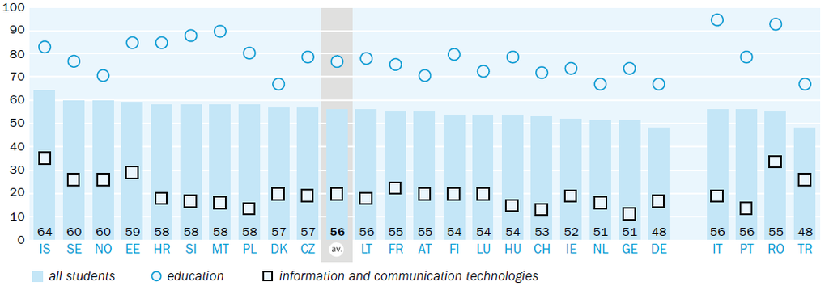

shares of female students (EUROSTUDENT)

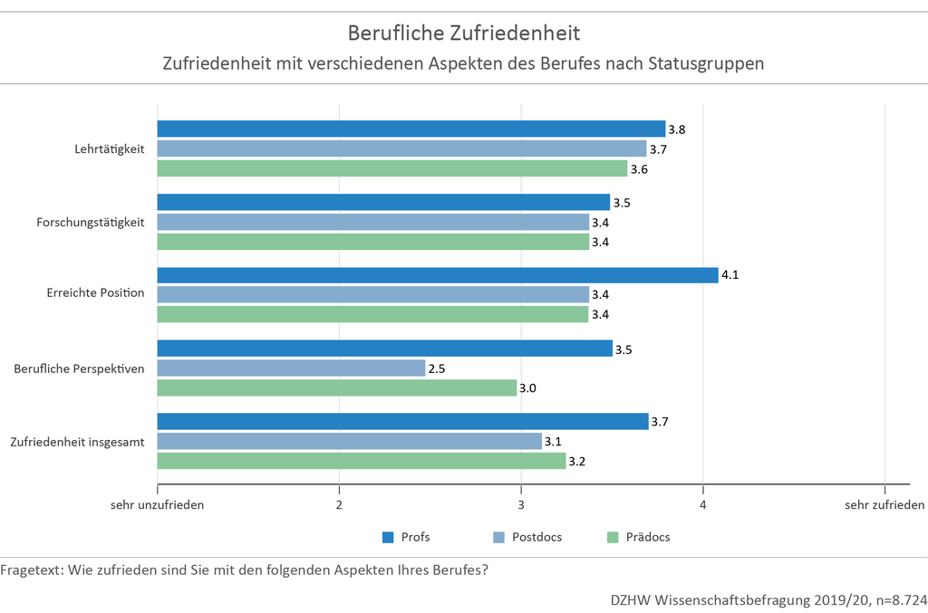

satisfaction with work environment (DZHW Science Survey)

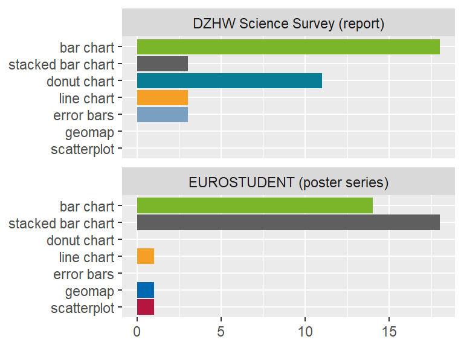

state of graphics

- Bar charts are famous for representations of categorical variables
- We can improve informativity of bar charts with panelized layouts and the colorblind-friendly DZHW color scheme

## The template for reports

However, sometimes we need printable reports with fixed layout.

- RMarkdown works with the DZHW report template, but manual editing of the Word document is required afterwards.

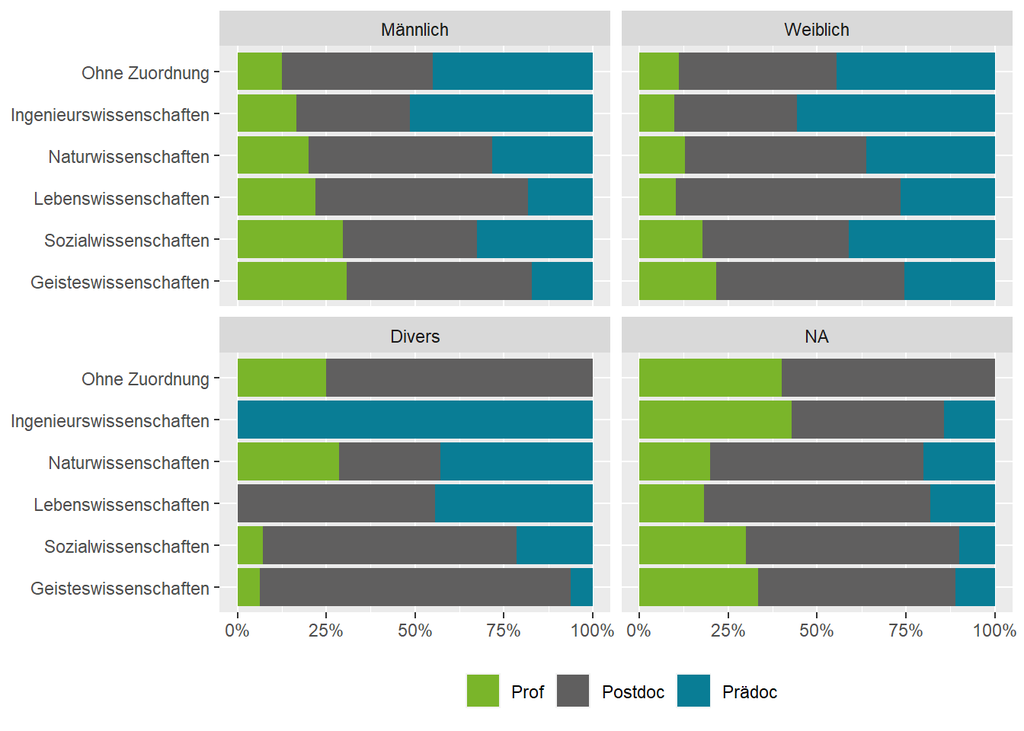

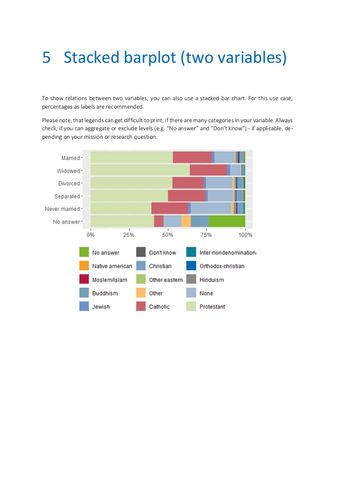

## The reporting guideline

- Practical display of RMarkdown applied to EUROSTUDENT VII and DZHW Science Survey data sets.
- e.g. how to write functions for plots:

```r
stacked_bars_cross <- function(data, column1,column2, ...) {...}
```

- …which can then be applied to different data sets:

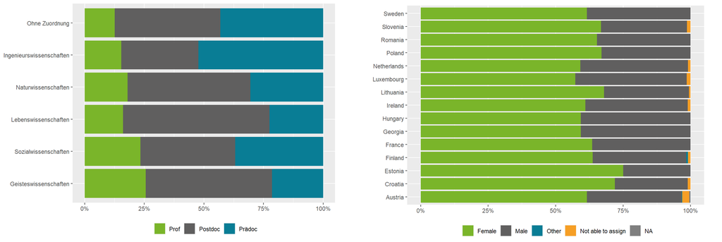

## The R/Shiny dashboard

- Dashboards make use of aggregated data sets which can be made openly available
- we have prepared a proof of concept

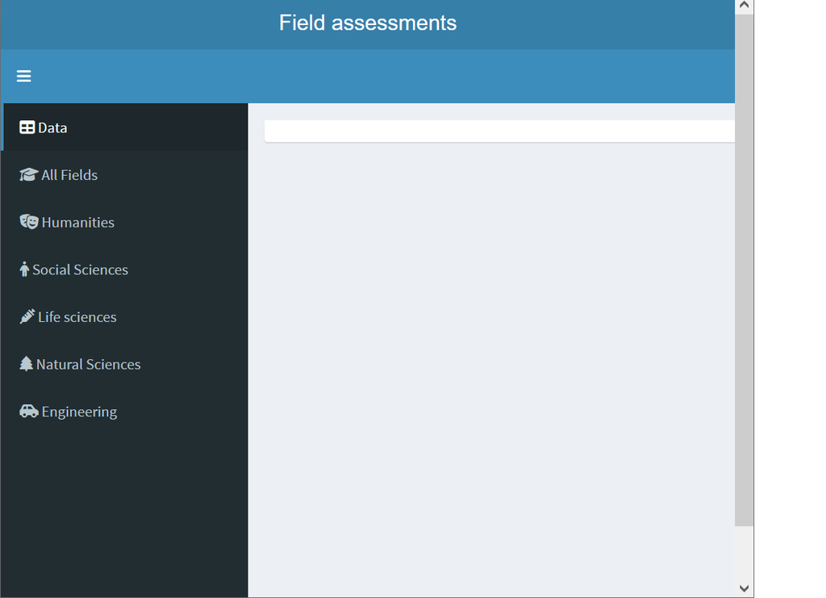

## Workflow: Blend text production and computation!

- start an RMarkdown report (see template)
- write functions for visualizations and apply them to your data set (see guideline)
- add text and compile an html report
- share your source code in a FAIR way
- render your code again as docx to a printable report
- move your analyses to an RMarkdown presentation and present them at conferences
- move your functions to an R/Shiny app and have people play with (a part of) your data set (see documentation)
- … and reuse your functions applying them to other data sets

## Possible next steps

Near future: Implement report template

- Incorporate suggestions from todays feedback (Thank you!)
- Discuss further improvements with the community at DZHW
- get approval from DZHW
- distribute with other templates (hopefully)

Distant future: Make a larger step towards Open Science

- have a common knowledge base at DZHW
- further develop template(s) as a community
- collect best-practice examples with shared code in a repository at DZHW

## Thank you!

Please find our files on GitHub:

https://github.com/jhartstein/DEiVHERSS/

## References

Allaire, JJ, Yihui Xie, Christophe Dervieux, Jonathan McPherson, Javier Luraschi, Kevin Ushey, Aron Atkins, et al. 2023. Rmarkdown: Dynamic Documents for r. https://github.com/rstudio/rmarkdown.

Ambrasat, Jens, Christophe Heger, Gregor Fabian, and Annegret Rucker. 2022. “DZHW-Wissenschaftsbefragung 2019. Datenerhebung: 2019/2020. Version: 2.0.0. Datenpaketzugangsweg: SUF: Remote-Desktop.” Edited by Anne Weber, Andreas Daniel, and Henrike Schmidtchen. Hannover: FDZ-DZHW. https://doi.org/10.21249/DZHW:scs2019:2.0.0.

Cuppen, Joris, Ardita Muja, Kristina Hauschildt, Andreas Daniel, Daniel Buck, Sylvia Mandl, and Martin Unger. 2023. “Eurostudent VII. Datenerhebung: 2019-2021. Version: 3.1.0. Datenpaketzugangsweg: SUF: Download.” Edited by Andreas Daniel, Daniel Buck, and Marten Wallis. Hannover: FDZ-DZHW. https://doi.org/10.21249/DZHW:es7:3.1.0.

Wickham, Hadley. 2016. Ggplot2: Elegant Graphics for Data Analysis. Springer-Verlag New York. https://ggplot2.tidyverse.org.

Wickham, Hadley, Mara Averick, Jennifer Bryan, Winston Chang, Lucy D’Agostino McGowan, Romain François, Garrett Grolemund, et al. 2019. “Welcome to the tidyverse.” Journal of Open Source Software 4 (43): 1686. https://doi.org/10.21105/joss.01686.

Wickham, Hadley, Evan Miller, and Danny Smith. 2023. Haven: Import and Export ’SPSS’, ’Stata’ and ’SAS’ Files. https://CRAN.R-project.org/package=haven.